# Mini-Project 2

Rocio Jaime and Sophie Li

October 31, 2017

# Some Insight Into Individuals Who Donated to Campaigns

```r
state_household_income <- read.csv(curl('https://raw.githubusercontent.com/sophieml/sds192-mp2/master/state_household_income.csv'))
```

```r
# creates function to assign group type of occupation to individual occupations
set_occ_type <- function(data, occupations, type) {
  data$occ_type[which(is.element(data$occ_type, occupations))] = type
  return(data)
}
#filters and summarizes individuals table so that occupations with over 10,000 donors are shown
#assigns occupation types to groups of occupations
most_common_occupations <- individuals %>%
  group_by(occupation) %>%
  summarize(num_occ = n()) %>%
  filter(num_occ > 10000) %>%
  mutate(occupation = tolower(occupation)) %>%
  mutate(occ_type = occupation) %>%
  set_occ_type(c('',
                 'information requested per best efforts',
                 'information requested',
                 'requested'), NA) %>%
  set_occ_type(c('retired',
                 'homemaker',
                 'not employed',
                 'none'), 'not working') %>%
  set_occ_type(c('attorney',
                 'lawyer'), 'law') %>%
  set_occ_type(c('physician',
                 'dentist'),'healthcare') %>%
  set_occ_type(c('president',
                 'executive',
                 'ceo',
                 'vice president',
                 'chairman',
                 'director'), 'executive') %>%
  set_occ_type(c('consultant',
                 'manager',
                 'sales'), 'business') %>%
  set_occ_type(c('owner',
                 'business owner',
                 'self-employed'), 'self employed') %>%
  set_occ_type(c('professor',
                 'teacher',
                 'principal'), 'education') %>%
  set_occ_type(c('real estate broker',
                 'realtor'), 'real estate') %>%
  set_occ_type(c('banker',
                 'investor',
                 'cpa'), 'finance') %>%
  set_occ_type(c('partner',
                 'writer',
                 'farmer'), 'other') %>%
  filter(!is.na(occ_type)) %>%
  arrange(desc(num_occ))
```

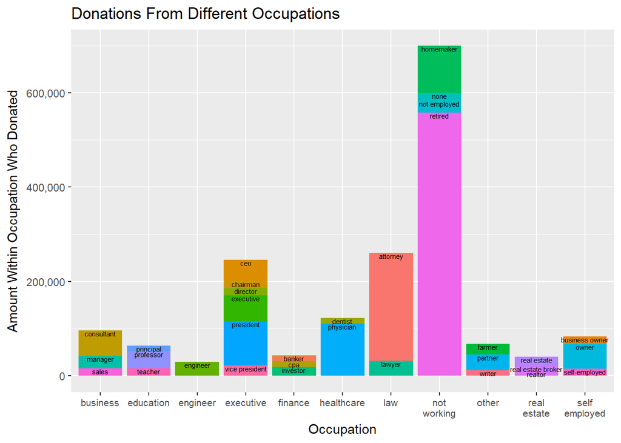

```r
#plots a stacked bar chart of the top donor occupations
ggplot(most_common_occupations, aes(x = occ_type, y = num_occ, fill = occupation)) +
  geom_col(position = 'stack') +
  geom_text(aes(label = occupation), size = 2, position = 'stack', vjust = 1) +
  labs(x = "Occupation", y = "Amount Within Occupation Who Donated", title = "Donations From Different Occupations", color = "Occupations") +
  ylim(0, 600000) +
  scale_x_discrete(labels = scales::wrap_format(0.5)) +
  scale_y_continuous(label = scales::comma) +
  theme(axis.text.x = element_text(size = 8),
        legend.position="none")
```

Our next graph offers a more clear comparison of the different occupations within each career field. As you can see, retired people far outnumber all other occupation categories. For clarification, the occupations in the data are not limited to those included in this graphic. Since this data was so large, we only included the specific occupations with more than 10,000 donors. This also helped avoid clutter.

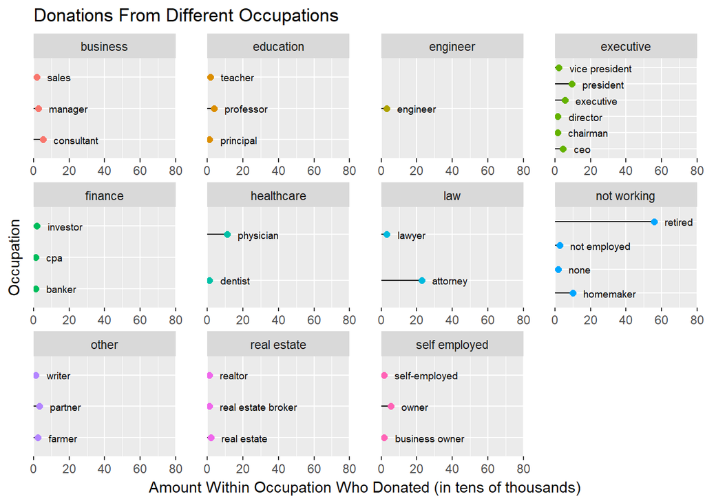

```r
#plots a segmented chart of the same data, but faceted for occupation type
ggplot(most_common_occupations, aes(x = num_occ, y = occupation, fill = occ_type)) +
  geom_segment(aes(x = 0, y = occupation, xend = num_occ, yend = occupation)) +
  geom_point(aes(x = num_occ, y = occupation, color = occ_type), size = 2) +
  geom_text(aes(x = num_occ + 60000, y = occupation, label = occupation), size = 2.5, hjust = 0) +
  labs(y = "Occupation", x = "Amount Within Occupation Who Donated (in tens of thousands)", title = "Donations From Different Occupations", color = "Occupations") +
  scale_y_discrete(labels = scales::wrap_format(0.5)) +
  scale_x_continuous(labels = function(x)x / 10000, expand = c(0,0), limits = c(0, 800000)) +
  facet_wrap(~ occ_type, scales = 'free') +
  theme(axis.text.y = element_blank(),
        axis.ticks.y = element_blank(),
        legend.position="none",
        panel.spacing.x = unit(20, 'pt'))
```

In this graphic we took the median income and mean amount donated for state to see if states with higher incomes donated more. We were expecting a strong linear correlation, so this graph was surprising. Although this graph is linear, the correlation is not has strong as one may suspect. In addition, the maximum donation per state seems to have only a weak correlation with household income.

```r
#takes the individuals data set and finds the mean and max contributions per state
state_contributions <- individuals %>%
  filter( individuals$state %in%candidates$cand_office_state) %>%
  group_by(state) %>%
  summarize(mean_amt = mean(abs(transaction_amt), na.rm = TRUE), max_amt = max(transaction_amt)) %>%
  arrange(desc(mean_amt))
```

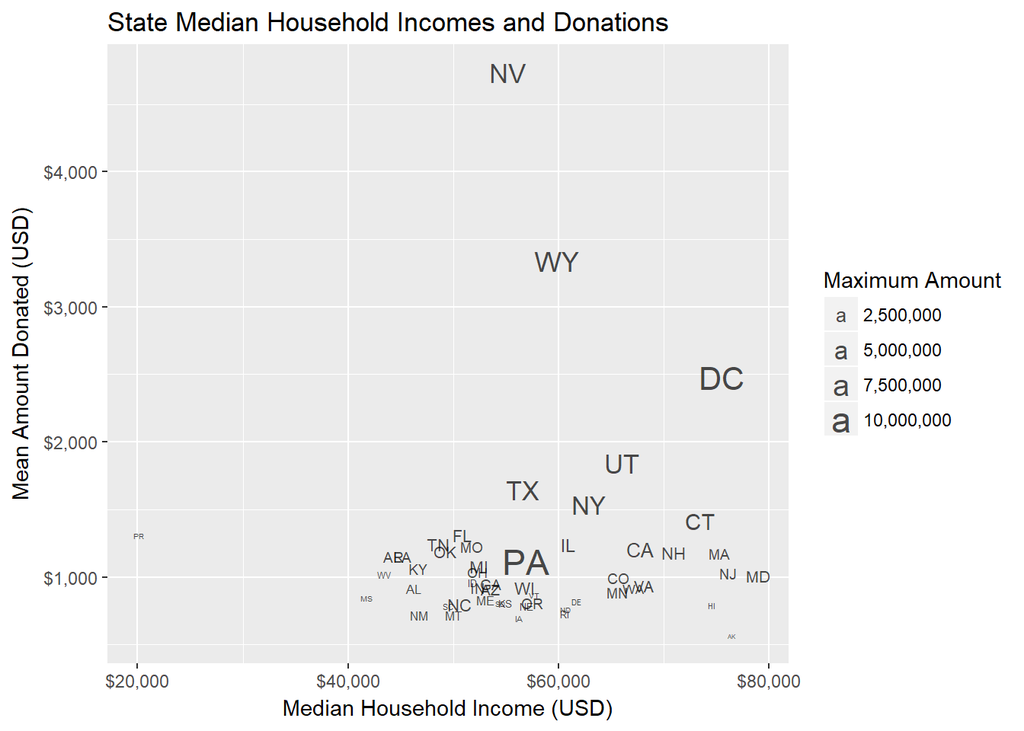

```r
#joins state_contributions to state_household_income (from csv)
state_data <- left_join(state_contributions, state_household_income, by = 'state') %>%
  filter(!is.na(household_income))

#plots median household income, mean donation amount, and max donation
ggplot(state_data, aes(x = household_income, y = mean_amt)) +
  geom_text(aes(label = state, size = max_amt), alpha = 0.7) +
  labs(x = "Median Household Income (USD)", y = "Mean Amount Donated (USD)", title = "State Median Household Incomes and Donations", size = "Maximum Amount") +
  scale_y_continuous(label = scales::dollar) +
  scale_x_continuous(label = scales::dollar) +
  scale_size_continuous(labels = scales::comma)
```